# Risk Factor Analysis

## Outcome Variable

**Outcome Variable:** ever_swasted

## Predictor Variables

**Intervention Variable:** hfoodsec

**Adjustment Set:**

- arm
- sex
- W_mage
- meducyrs
- feducyrs
- hhwealth_quart
- vagbrth
- W_nrooms
- W_nchldlt5
- brthmon
- W_parity
- impfloor
- impsan
- safeh20
- delta_W_mage
- delta_meducyrs
- delta_feducyrs
- delta_hhwealth_quart
- delta_vagbrth
- delta_W_nrooms
- delta_W_nchldlt5
- delta_brthmon
- delta_W_parity
- delta_impfloor
- delta_impsan
- delta_safeh20

## Stratifying Variables

The analysis was stratified on these variable(s):

- agecat
- studyid
- country

## Data Summary

| agecat | studyid | country | hfoodsec | ever_swasted | n_cell | n |
| --- | --- | --- | --- | --- | --- | --- |
| 0-24 months | GMS-Nepal | NEPAL | Food Secure | 0 | 348 | 663 |
| 0-24 months | GMS-Nepal | NEPAL | Food Secure | 1 | 123 | 663 |
| 0-24 months | GMS-Nepal | NEPAL | Mildly Food Insecure | 0 | 82 | 663 |
| 0-24 months | GMS-Nepal | NEPAL | Mildly Food Insecure | 1 | 23 | 663 |
| 0-24 months | GMS-Nepal | NEPAL | Food Insecure | 0 | 65 | 663 |
| 0-24 months | GMS-Nepal | NEPAL | Food Insecure | 1 | 22 | 663 |
| 0-24 months | JiVitA-3 | BANGLADESH | Food Secure | 0 | 8193 | 17375 |
| 0-24 months | JiVitA-3 | BANGLADESH | Food Secure | 1 | 503 | 17375 |
| 0-24 months | JiVitA-3 | BANGLADESH | Mildly Food Insecure | 0 | 5404 | 17375 |
| 0-24 months | JiVitA-3 | BANGLADESH | Mildly Food Insecure | 1 | 380 | 17375 |
| 0-24 months | JiVitA-3 | BANGLADESH | Food Insecure | 0 | 2662 | 17375 |
| 0-24 months | JiVitA-3 | BANGLADESH | Food Insecure | 1 | 233 | 17375 |
| 0-24 months | JiVitA-4 | BANGLADESH | Food Secure | 0 | 2580 | 5399 |
| 0-24 months | JiVitA-4 | BANGLADESH | Food Secure | 1 | 169 | 5399 |
| 0-24 months | JiVitA-4 | BANGLADESH | Mildly Food Insecure | 0 | 1818 | 5399 |
| 0-24 months | JiVitA-4 | BANGLADESH | Mildly Food Insecure | 1 | 130 | 5399 |
| 0-24 months | JiVitA-4 | BANGLADESH | Food Insecure | 0 | 660 | 5399 |
| 0-24 months | JiVitA-4 | BANGLADESH | Food Insecure | 1 | 42 | 5399 |
| 0-24 months | MAL-ED | BANGLADESH | Food Secure | 0 | 146 | 194 |
| 0-24 months | MAL-ED | BANGLADESH | Food Secure | 1 | 15 | 194 |
| 0-24 months | MAL-ED | BANGLADESH | Mildly Food Insecure | 0 | 4 | 194 |
| 0-24 months | MAL-ED | BANGLADESH | Mildly Food Insecure | 1 | 0 | 194 |
| 0-24 months | MAL-ED | BANGLADESH | Food Insecure | 0 | 26 | 194 |
| 0-24 months | MAL-ED | BANGLADESH | Food Insecure | 1 | 3 | 194 |
| 0-24 months | MAL-ED | BRAZIL | Food Secure | 0 | 3 | 129 |
| 0-24 months | MAL-ED | BRAZIL | Food Secure | 1 | 0 | 129 |
| 0-24 months | MAL-ED | BRAZIL | Mildly Food Insecure | 0 | 11 | 129 |
| 0-24 months | MAL-ED | BRAZIL | Mildly Food Insecure | 1 | 0 | 129 |
| 0-24 months | MAL-ED | BRAZIL | Food Insecure | 0 | 113 | 129 |
| 0-24 months | MAL-ED | BRAZIL | Food Insecure | 1 | 2 | 129 |
| 0-24 months | MAL-ED | INDIA | Food Secure | 0 | 170 | 212 |
| 0-24 months | MAL-ED | INDIA | Food Secure | 1 | 20 | 212 |
| 0-24 months | MAL-ED | INDIA | Mildly Food Insecure | 0 | 3 | 212 |
| 0-24 months | MAL-ED | INDIA | Mildly Food Insecure | 1 | 2 | 212 |
| 0-24 months | MAL-ED | INDIA | Food Insecure | 0 | 16 | 212 |
| 0-24 months | MAL-ED | INDIA | Food Insecure | 1 | 1 | 212 |
| 0-24 months | MAL-ED | NEPAL | Food Secure | 0 | 92 | 128 |
| 0-24 months | MAL-ED | NEPAL | Food Secure | 1 | 2 | 128 |
| 0-24 months | MAL-ED | NEPAL | Mildly Food Insecure | 0 | 14 | 128 |
| 0-24 months | MAL-ED | NEPAL | Mildly Food Insecure | 1 | 1 | 128 |
| 0-24 months | MAL-ED | NEPAL | Food Insecure | 0 | 18 | 128 |
| 0-24 months | MAL-ED | NEPAL | Food Insecure | 1 | 1 | 128 |
| 0-24 months | MAL-ED | PERU | Food Secure | 0 | 26 | 113 |
| 0-24 months | MAL-ED | PERU | Food Secure | 1 | 1 | 113 |
| 0-24 months | MAL-ED | PERU | Mildly Food Insecure | 0 | 29 | 113 |
| 0-24 months | MAL-ED | PERU | Mildly Food Insecure | 1 | 0 | 113 |
| 0-24 months | MAL-ED | PERU | Food Insecure | 0 | 55 | 113 |
| 0-24 months | MAL-ED | PERU | Food Insecure | 1 | 2 | 113 |
| 0-24 months | MAL-ED | SOUTH AFRICA | Food Secure | 0 | 125 | 233 |
| 0-24 months | MAL-ED | SOUTH AFRICA | Food Secure | 1 | 7 | 233 |
| 0-24 months | MAL-ED | SOUTH AFRICA | Mildly Food Insecure | 0 | 18 | 233 |
| 0-24 months | MAL-ED | SOUTH AFRICA | Mildly Food Insecure | 1 | 1 | 233 |
| 0-24 months | MAL-ED | SOUTH AFRICA | Food Insecure | 0 | 76 | 233 |
| 0-24 months | MAL-ED | SOUTH AFRICA | Food Insecure | 1 | 6 | 233 |
| 0-24 months | NIH-Birth | BANGLADESH | Food Secure | 0 | 83 | 624 |
| 0-24 months | NIH-Birth | BANGLADESH | Food Secure | 1 | 11 | 624 |
| 0-24 months | NIH-Birth | BANGLADESH | Mildly Food Insecure | 0 | 408 | 624 |
| 0-24 months | NIH-Birth | BANGLADESH | Mildly Food Insecure | 1 | 80 | 624 |
| 0-24 months | NIH-Birth | BANGLADESH | Food Insecure | 0 | 34 | 624 |
| 0-24 months | NIH-Birth | BANGLADESH | Food Insecure | 1 | 8 | 624 |
| 0-24 months | NIH-Crypto | BANGLADESH | Food Secure | 0 | 409 | 758 |
| 0-24 months | NIH-Crypto | BANGLADESH | Food Secure | 1 | 44 | 758 |
| 0-24 months | NIH-Crypto | BANGLADESH | Mildly Food Insecure | 0 | 202 | 758 |
| 0-24 months | NIH-Crypto | BANGLADESH | Mildly Food Insecure | 1 | 17 | 758 |
| 0-24 months | NIH-Crypto | BANGLADESH | Food Insecure | 0 | 81 | 758 |
| 0-24 months | NIH-Crypto | BANGLADESH | Food Insecure | 1 | 5 | 758 |

The following strata were considered:

- agecat: 0-24 months, studyid: GMS-Nepal, country: NEPAL
- agecat: 0-24 months, studyid: JiVitA-3, country: BANGLADESH
- agecat: 0-24 months, studyid: JiVitA-4, country: BANGLADESH
- agecat: 0-24 months, studyid: MAL-ED, country: BANGLADESH
- agecat: 0-24 months, studyid: MAL-ED, country: BRAZIL
- agecat: 0-24 months, studyid: MAL-ED, country: INDIA
- agecat: 0-24 months, studyid: MAL-ED, country: NEPAL
- agecat: 0-24 months, studyid: MAL-ED, country: PERU
- agecat: 0-24 months, studyid: MAL-ED, country: SOUTH AFRICA
- agecat: 0-24 months, studyid: NIH-Birth, country: BANGLADESH
- agecat: 0-24 months, studyid: NIH-Crypto, country: BANGLADESH

### Dropped Strata

Some strata were dropped due to rare outcomes:

- agecat: 0-24 months, studyid: MAL-ED, country: BANGLADESH
- agecat: 0-24 months, studyid: MAL-ED, country: BRAZIL
- agecat: 0-24 months, studyid: MAL-ED, country: INDIA
- agecat: 0-24 months, studyid: MAL-ED, country: NEPAL
- agecat: 0-24 months, studyid: MAL-ED, country: PERU
- agecat: 0-24 months, studyid: MAL-ED, country: SOUTH AFRICA

## Methods Detail

We're interested in the causal parameters $E[Y_a]$ for all values of $a \in \mathcal{A}$. These parameters represent the mean outcome if, possibly contrary to fact, we intervened to set all units to have $A=a$. Under the randomization and positivity assumptions, these are identified by the statistical parameters $\psi_a=E_W[E_{Y|A,W}(Y|A=a,W)]$. In addition, we're interested in the mean of $Y$, $E[Y]$ under no intervention (the observed mean). We will estimate these parameters by using SuperLearner to fit the relevant likelihood factors -- $E_{Y|A,W}(Y|A=a,W)$ and $p(A=a|W)$, and then updating our likelihood fit using a joint TMLE.

For unadjusted analyses ($W=\{\}$), initial likelihoods were estimated using Lrnr_glm to estimate the simple $E(Y|A)$ and Lrnr_mean to estimate $p(A)$. For adjusted analyses, a small library containing Lrnr_glmnet, Lrnr_xgboost, and Lrnr_mean was used.

Having estimated these parameters, we will then use the delta method to estimate relative risks and attributable risks relative to a prespecified baseline level of $A$.

# Results Detail

## Results Plots

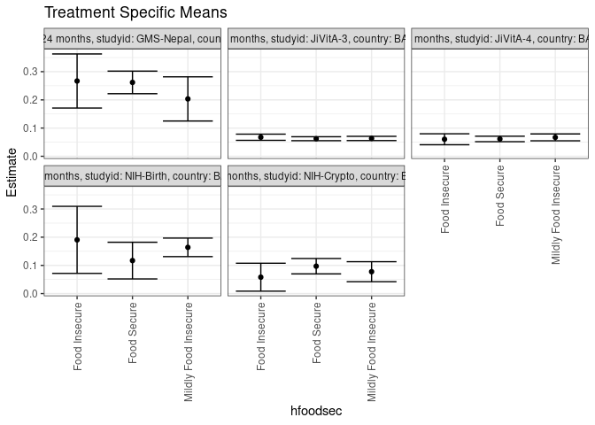

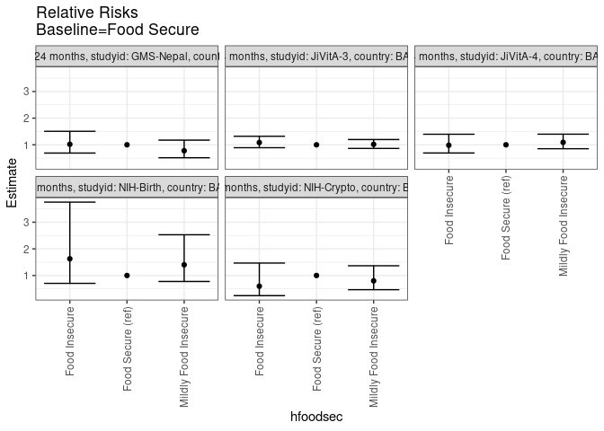

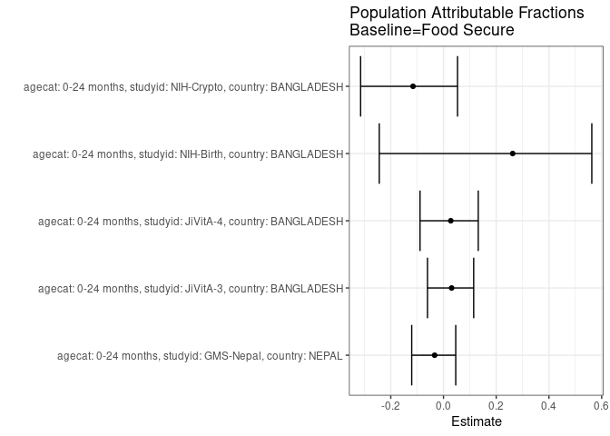

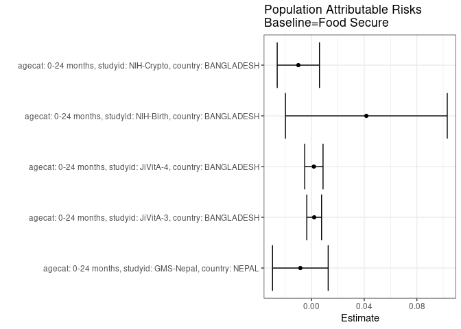

## Results Table

### Parameter: TSM

| agecat | studyid | country | intervention_level | baseline_level | estimate | ci_lower | ci_upper |
| --- | --- | --- | --- | --- | --- | --- | --- |
| 0-24 months | GMS-Nepal | NEPAL | Food Secure | NA | 0.2619192 | 0.2219480 | 0.3018904 |
| 0-24 months | GMS-Nepal | NEPAL | Mildly Food Insecure | NA | 0.2034078 | 0.1250925 | 0.2817232 |
| 0-24 months | GMS-Nepal | NEPAL | Food Insecure | NA | 0.2668966 | 0.1710052 | 0.3627879 |
| 0-24 months | JiVitA-3 | BANGLADESH | Food Secure | NA | 0.0622482 | 0.0552314 | 0.0692650 |
| 0-24 months | JiVitA-3 | BANGLADESH | Mildly Food Insecure | NA | 0.0632733 | 0.0557310 | 0.0708155 |
| 0-24 months | JiVitA-3 | BANGLADESH | Food Insecure | NA | 0.0675089 | 0.0565021 | 0.0785157 |
| 0-24 months | JiVitA-4 | BANGLADESH | Food Secure | NA | 0.0614113 | 0.0517129 | 0.0711097 |
| 0-24 months | JiVitA-4 | BANGLADESH | Mildly Food Insecure | NA | 0.0670434 | 0.0548897 | 0.0791972 |
| 0-24 months | JiVitA-4 | BANGLADESH | Food Insecure | NA | 0.0603353 | 0.0408885 | 0.0797821 |
| 0-24 months | NIH-Birth | BANGLADESH | Food Secure | NA | 0.1170213 | 0.0519874 | 0.1820552 |
| 0-24 months | NIH-Birth | BANGLADESH | Mildly Food Insecure | NA | 0.1639344 | 0.1310612 | 0.1968076 |
| 0-24 months | NIH-Birth | BANGLADESH | Food Insecure | NA | 0.1904762 | 0.0716241 | 0.3093283 |
| 0-24 months | NIH-Crypto | BANGLADESH | Food Secure | NA | 0.0971302 | 0.0698420 | 0.1244185 |
| 0-24 months | NIH-Crypto | BANGLADESH | Mildly Food Insecure | NA | 0.0776256 | 0.0421631 | 0.1130880 |
| 0-24 months | NIH-Crypto | BANGLADESH | Food Insecure | NA | 0.0581395 | 0.0086499 | 0.1076292 |

### Parameter: E(Y)

| agecat | studyid | country | intervention_level | baseline_level | estimate | ci_lower | ci_upper |
| --- | --- | --- | --- | --- | --- | --- | --- |
| 0-24 months | GMS-Nepal | NEPAL | NA | NA | 0.2533937 | 0.2202605 | 0.2865268 |
| 0-24 months | JiVitA-3 | BANGLADESH | NA | NA | 0.0642302 | 0.0601218 | 0.0683386 |
| 0-24 months | JiVitA-4 | BANGLADESH | NA | NA | 0.0631598 | 0.0562585 | 0.0700612 |
| 0-24 months | NIH-Birth | BANGLADESH | NA | NA | 0.1586538 | 0.1299648 | 0.1873429 |
| 0-24 months | NIH-Crypto | BANGLADESH | NA | NA | 0.0870712 | 0.0669870 | 0.1071555 |

### Parameter: RR

| agecat | studyid | country | intervention_level | baseline_level | estimate | ci_lower | ci_upper |
| --- | --- | --- | --- | --- | --- | --- | --- |
| 0-24 months | GMS-Nepal | NEPAL | Food Secure | Food Secure | 1.0000000 | 1.0000000 | 1.000000 |
| 0-24 months | GMS-Nepal | NEPAL | Mildly Food Insecure | Food Secure | 0.7766053 | 0.5133280 | 1.174913 |
| 0-24 months | GMS-Nepal | NEPAL | Food Insecure | Food Secure | 1.0190033 | 0.6895169 | 1.505935 |
| 0-24 months | JiVitA-3 | BANGLADESH | Food Secure | Food Secure | 1.0000000 | 1.0000000 | 1.000000 |
| 0-24 months | JiVitA-3 | BANGLADESH | Mildly Food Insecure | Food Secure | 1.0164681 | 0.8630994 | 1.197090 |
| 0-24 months | JiVitA-3 | BANGLADESH | Food Insecure | Food Secure | 1.0845126 | 0.8911265 | 1.319866 |
| 0-24 months | JiVitA-4 | BANGLADESH | Food Secure | Food Secure | 1.0000000 | 1.0000000 | 1.000000 |
| 0-24 months | JiVitA-4 | BANGLADESH | Mildly Food Insecure | Food Secure | 1.0917119 | 0.8522757 | 1.398415 |
| 0-24 months | JiVitA-4 | BANGLADESH | Food Insecure | Food Secure | 0.9824782 | 0.6914628 | 1.395973 |
| 0-24 months | NIH-Birth | BANGLADESH | Food Secure | Food Secure | 1.0000000 | 1.0000000 | 1.000000 |
| 0-24 months | NIH-Birth | BANGLADESH | Mildly Food Insecure | Food Secure | 1.4008942 | 0.7759210 | 2.529258 |
| 0-24 months | NIH-Birth | BANGLADESH | Food Insecure | Food Secure | 1.6277056 | 0.7058100 | 3.753738 |
| 0-24 months | NIH-Crypto | BANGLADESH | Food Secure | Food Secure | 1.0000000 | 1.0000000 | 1.000000 |
| 0-24 months | NIH-Crypto | BANGLADESH | Mildly Food Insecure | Food Secure | 0.7991905 | 0.4674468 | 1.366370 |
| 0-24 months | NIH-Crypto | BANGLADESH | Food Insecure | Food Secure | 0.5985729 | 0.2442425 | 1.466942 |

### Parameter: PAR

| agecat | studyid | country | intervention_level | baseline_level | estimate | ci_lower | ci_upper |
| --- | --- | --- | --- | --- | --- | --- | --- |
| 0-24 months | GMS-Nepal | NEPAL | Food Secure | NA | -0.0085255 | -0.0296694 | 0.0126183 |
| 0-24 months | JiVitA-3 | BANGLADESH | Food Secure | NA | 0.0019821 | -0.0036349 | 0.0075990 |
| 0-24 months | JiVitA-4 | BANGLADESH | Food Secure | NA | 0.0017485 | -0.0052116 | 0.0087087 |
| 0-24 months | NIH-Birth | BANGLADESH | Food Secure | NA | 0.0416326 | -0.0198347 | 0.1030999 |
| 0-24 months | NIH-Crypto | BANGLADESH | Food Secure | NA | -0.0100590 | -0.0261209 | 0.0060029 |

### Parameter: PAF

| agecat | studyid | country | intervention_level | baseline_level | estimate | ci_lower | ci_upper |
| --- | --- | --- | --- | --- | --- | --- | --- |
| 0-24 months | GMS-Nepal | NEPAL | Food Secure | NA | -0.0336455 | -0.1204946 | 0.0464720 |
| 0-24 months | JiVitA-3 | BANGLADESH | Food Secure | NA | 0.0308586 | -0.0607200 | 0.1145306 |
| 0-24 months | JiVitA-4 | BANGLADESH | Food Secure | NA | 0.0276844 | -0.0889783 | 0.1318491 |
| 0-24 months | NIH-Birth | BANGLADESH | Food Secure | NA | 0.2624113 | -0.2436437 | 0.5625459 |
| 0-24 months | NIH-Crypto | BANGLADESH | Food Secure | NA | -0.1155261 | -0.3143298 | 0.0532068 |